# Week 2 Day 1 Homework

# 1 MVP

## 1.1 Hypothesis testing - practical

### Question 1

```r
library(tidyverse)
library(infer)

sleep <- msleep
```

```r
glimpse(sleep)
```

```
## Rows: 83
## Columns: 11
## $ name         <chr> "Cheetah", "Owl monkey", "Mountain beaver", "Greater shor…
## $ genus        <chr> "Acinonyx", "Aotus", "Aplodontia", "Blarina", "Bos", "Bra…
## $ vore         <chr> "carni", "omni", "herbi", "omni", "herbi", "herbi", "carn…
## $ order        <chr> "Carnivora", "Primates", "Rodentia", "Soricomorpha", "Art…
## $ conservation <chr> "lc", NA, "nt", "lc", "domesticated", NA, "vu", NA, "dome…
## $ sleep_total  <dbl> 12.1, 17.0, 14.4, 14.9, 4.0, 14.4, 8.7, 7.0, 10.1, 3.0, 5…
## $ sleep_rem    <dbl> NA, 1.8, 2.4, 2.3, 0.7, 2.2, 1.4, NA, 2.9, NA, 0.6, 0.8, …
## $ sleep_cycle  <dbl> NA, NA, NA, 0.1333333, 0.6666667, 0.7666667, 0.3833333, N…
## $ awake        <dbl> 11.9, 7.0, 9.6, 9.1, 20.0, 9.6, 15.3, 17.0, 13.9, 21.0, 1…
## $ brainwt      <dbl> NA, 0.01550, NA, 0.00029, 0.42300, NA, NA, NA, 0.07000, 0…
## $ bodywt       <dbl> 50.000, 0.480, 1.350, 0.019, 600.000, 3.850, 20.490, 0.04…
```

```r
skimr::skim(sleep)
```

Data summary

| Name | sleep |
| --- | --- |
| Number of rows | 83 |
| Number of columns | 11 |
| _______________________ |  |
| Column type frequency: |  |
| character | 5 |
| numeric | 6 |
| ________________________ |  |
| Group variables | None |

**Variable type: character**

| skim_variable | n_missing | complete_rate | min | max | empty | n_unique | whitespace |
| --- | --- | --- | --- | --- | --- | --- | --- |
| name | 0 | 1.00 | 3 | 30 | 0 | 83 | 0 |
| genus | 0 | 1.00 | 3 | 13 | 0 | 77 | 0 |
| vore | 7 | 0.92 | 4 | 7 | 0 | 4 | 0 |
| order | 0 | 1.00 | 6 | 15 | 0 | 19 | 0 |
| conservation | 29 | 0.65 | 2 | 12 | 0 | 6 | 0 |

**Variable type: numeric**

| skim_variable | n_missing | complete_rate | mean | sd | p0 | p25 | p50 | p75 | p100 | hist |
| --- | --- | --- | --- | --- | --- | --- | --- | --- | --- | --- |
| sleep_total | 0 | 1.00 | 10.43 | 4.45 | 1.90 | 7.85 | 10.10 | 13.75 | 19.90 | ▅▅▇▆▂ |
| sleep_rem | 22 | 0.73 | 1.88 | 1.30 | 0.10 | 0.90 | 1.50 | 2.40 | 6.60 | ▇▆▂▁▁ |
| sleep_cycle | 51 | 0.39 | 0.44 | 0.36 | 0.12 | 0.18 | 0.33 | 0.58 | 1.50 | ▇▂▁▁▁ |
| awake | 0 | 1.00 | 13.57 | 4.45 | 4.10 | 10.25 | 13.90 | 16.15 | 22.10 | ▂▅▇▃▅ |
| brainwt | 27 | 0.67 | 0.28 | 0.98 | 0.00 | 0.00 | 0.01 | 0.13 | 5.71 | ▇▁▁▁▁ |
| bodywt | 0 | 1.00 | 166.14 | 786.84 | 0.00 | 0.17 | 1.67 | 41.75 | 6654.00 | ▇▁▁▁▁ |

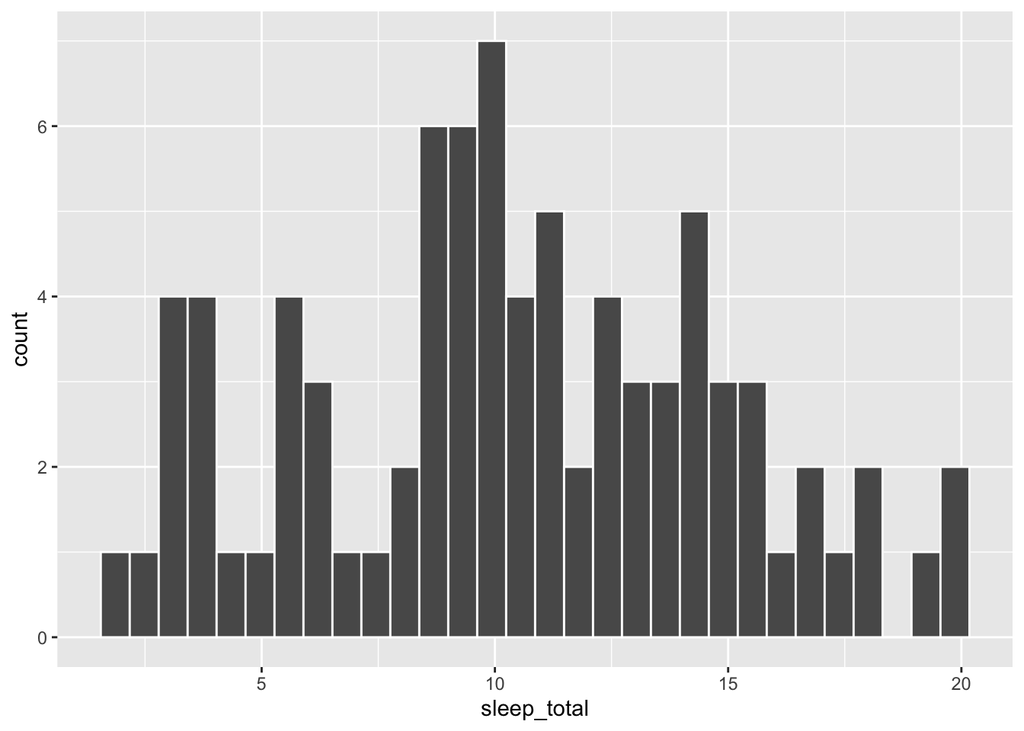

```r
sleep %>%
  ggplot(aes(sleep_total)) +
  geom_histogram(col = "white")
```

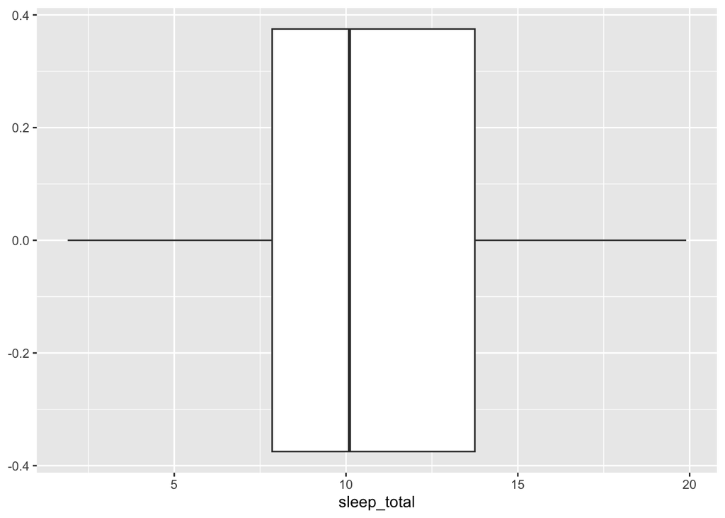

```r
sleep %>%
  ggplot(aes(sleep_total)) +
  geom_boxplot()
```

The median of sleep_total is just above 10 hours.

### Question 2

**1. Hypothesis**

H0: mean sleep_total = 7 hours a night  
HA: mean sleep_total != 7 hours a night

alpha: 0.05  
0.05 chosen as the outcome as this is a standard value used for alpha in non-critical analysis.

This is a one sample test on the mean.

**2. Calculate observed stat**

```r
mean_sleep <- sleep %>%
  summarise(mean_sleep = mean(sleep_total)) %>%
  pull()

mean_sleep
```

```
## [1] 10.43373
```

The mean value is above 10 hours, which seems very different from the 7 hours that the jabberwocky sleeps but lets test this statistically.

**3. Null distribution**

```r
null_dist <- sleep %>%
  specify(response = sleep_total) %>%
  hypothesise(null = "point", mu = 7) %>%
  generate(reps = 10000, type = "bootstrap") %>%
  calculate(stat = "mean")
```

**4. Visualise**

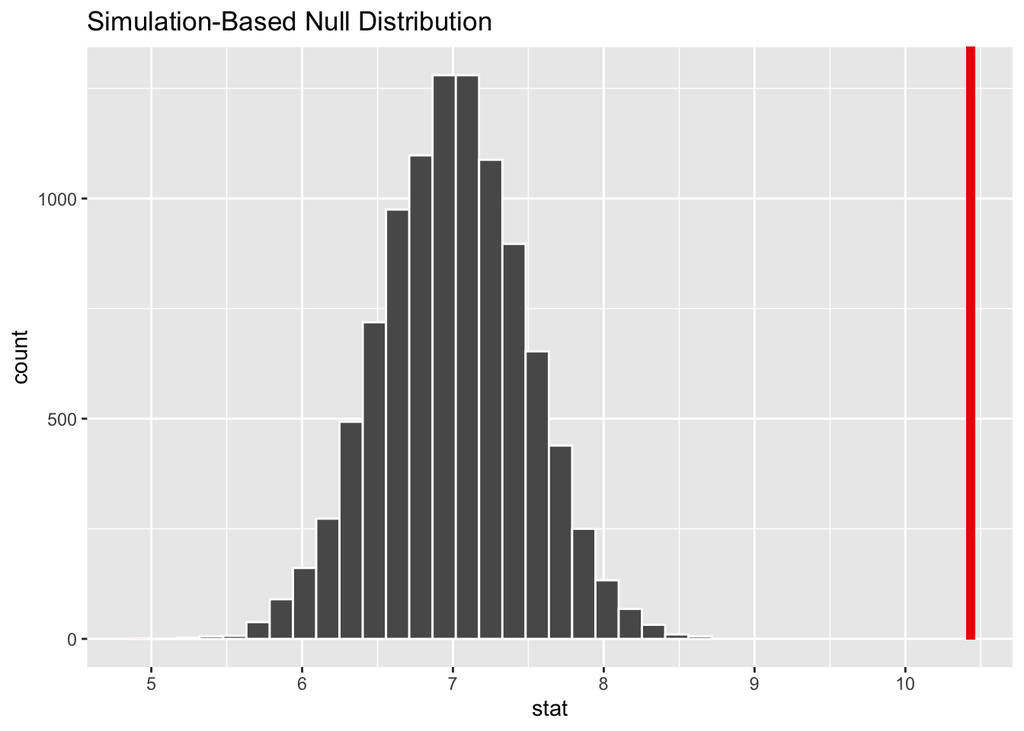

```r
null_dist %>%
  visualise(bins = 25) +
  shade_p_value(obs_stat = mean_sleep,
                direction = "both")
```

As expected the mean of the total_sleep for the animals in our dataset is much higher and appears far to the right of the null distribution. The p-value is expected to be very low.

**5. Calculate p-value**

```r
sleep_p_val <- null_dist %>%
  get_p_value(obs_stat = mean_sleep,
                direction = "both") %>%
  pull()
format.pval(sleep_p_val)
```

```
## [1] "< 2.22e-16"
```

The p-value is < 0.0001.

**6. Conclusions**

H0: mean sleep_total = 7 hours a night  
HA: mean sleep_total != 7 hours a night

The H0 hypothesis is rejected as the p value is < 0.0001 which is below our chosen alpha value of 0.05.

We can therefore say that the mean sleep_total for animals is our dataset is statistically different from the jabberwocky.

### Question 3

This is a two sample test. We are determining whether the sleep_total has a dependence on whether an animal is an omnivore or herbivore.

H0: omnivore sleep_total <= herbivore sleep_total  
HA: omnivore sleep_total > herbivore sleep_total

alpha: 0.05

```r
herbi_omni_sleep <- sleep %>%
  filter(vore %in% c("herbi", "omni")) %>%
  select(vore, sleep_total)

herbi_sleep <- herbi_omni_sleep %>%
  filter(vore == "herbi") %>%
  summarise(herbi_mean_sleep = mean(sleep_total))

omni_sleep <- herbi_omni_sleep %>%
  filter(vore == "omni") %>%
  summarise(omni_mean_sleep = mean(sleep_total))

sleep_diff = omni_sleep - herbi_sleep
```

From our dataset, on average omnivores sleep for 1.416 hours longer than herbivores.

```r
null_dist_omni_herbi <- herbi_omni_sleep %>%
  specify(sleep_total ~ vore) %>%
  hypothesise(null = "independence") %>%
  generate(reps = 10000, type = "permute") %>%
  calculate(stat = "diff in means",
            order = c("omni", "herbi"))
```

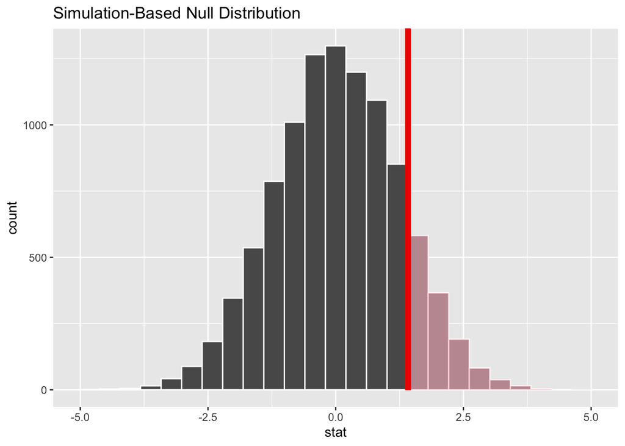

```r
null_dist_omni_herbi %>%
  visualise(bins = 25) +
  shade_p_value(obs_stat = sleep_diff,
                direction = "greater")
```

```r
null_dist_omni_herbi %>%
  get_p_value(obs_stat = sleep_diff,
                direction = "greater")
```

| p_value |
| --- |
| 0.1278 |

H0: omnivore sleep_total <= herbivore sleep_total  
HA: omnivore sleep_total > herbivore sleep_total

### Question 4

This is a one sample proportion test.

H0: proportion of domesticated animals <= 5%  
HA: proportion of domesticated animlas > 5%

alpha 0.05

The conservation column (which contains the domesticated status) contains a lot of NAs. The dataset is small and on inspection no domesticated animals (except maybe humans!) were found to have a NA for conservation.

For this reason the total number of rows in the msleep dataset were used to calculated the proportion of domesticated animals.

```r
# The null distribution analysis wouldn't run with yes, no and NA in the new is_dom. For the reasons stated above the NA values in this column were converted to "no"

sleep_dom_col <- sleep %>%
  mutate(is_dom = ifelse(conservation == "domesticated", "yes", "no"))

sleep_dom_col$is_dom <- sleep_dom_col$is_dom %>%
  replace_na("no")

prop <- sleep_dom_col %>%
  filter(is_dom == "yes") %>%
  summarise(prop_dom = n() / nrow(sleep)) %>%
  pull()
```

The proportion of domesticated animal types in the dataset is 12.05%.

```r
prop_null_dist <- sleep_dom_col %>%
  specify(response = is_dom, success = "yes") %>%
  hypothesise(null = "point", p = 0.05) %>%
  generate(reps = 20000, type = "draw") %>%
  calculate(stat = "prop")
```

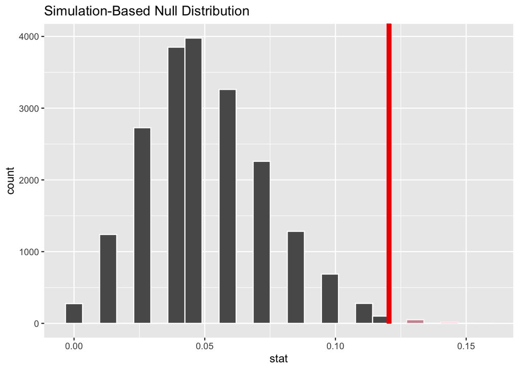

```r
prop_null_dist %>%
  visualise(bins = 25) +
  shade_p_value(obs_stat = prop,
                direction = "greater")
```

```r
prop_null_dist %>%
  get_p_value(obs_stat = prop,
                direction = "greater")
```

| p_value |
| --- |
| 0.0082 |

The p value is 0.01 which is less than our alpha of 0.05 therefore we can reject our null hypothesis and conclude that the proportion of domesticated animal types in the population of animal types is greater than 5%.

## 1.2 Hypothesis Testing - Defining the Hypothesis

### Question 1

**Test:** One sample proportion test  
**H0:** proportion of people who know of coffee shop <= 40%  
**HA:** proportion of people who know of coffee shop > 40%  
**Null distribution method:** draw

### Question 2

**Test:** Two sample test - proportion - independent  
**H0:** Group A CTR proportion >= Group B CTR  
**HA:** Group A CTR proportion < Group B CTR

The banner is currently at the right hand side which is where Group A see it so to keep the status the same, the null hypothesis should be that the click through proportion is the same or greater than for Group B where the banner is at the top.

**Null distribution method:** bootstrap (after wrangling data at start)

### Question 3

**Test:** One sample mean test  
**H0:** mean width = 145 mm  
**HA:** mean width != 145 mm  
**Null distribution method:** bootstrap

## 1.3 Hypothesis Testing - Interpreting Results

### Question 1

The calculated p-value (0.07) is greater than the chosen alpha (0.05) therefore we cannot reject the null hypothesis. We can reject the alternative hypothesis which states that more than 40% of the towns population have heard of the coffee shop. We were wrong and our boss was right :( Just don’t tell them you’ve done the analysis!

### Question 2

The calculated p-value (0.006) is lower than the chosen alpha (0.01). We can therefore reject the null hypothesis which states that the click through rate is the same or higher when the banner is at the side. Our data shows the click through rate is higher when the banner is positioned at the top of the page.

### Question 3

The calculated p-value (0.55) is higher than the chose alpha (0.05). We can therefore reject the alternative hypothesis. The data tells us the parts are within specification.

Removing variables created in MVP section

```r
rm(list = ls())
```

# Extensions

## Market Basket Analysis

```r
transactions <- read_csv("data/online_retail_subset.csv") %>% janitor::clean_names()
glimpse(transactions)
```

```
## Rows: 30,000
## Columns: 7
## $ invoice_no   <chr> "536365", "536365", "536365", "536365", "536365", "536365…
## $ stock_code   <chr> "85123A", "71053", "84406B", "84029G", "84029E", "22752",…
## $ description  <chr> "WHITE HANGING HEART T-LIGHT HOLDER", "WHITE METAL LANTER…
## $ invoice_date <chr> "12/1/10 8:26", "12/1/10 8:26", "12/1/10 8:26", "12/1/10 …
## $ unit_price   <dbl> 2.55, 3.39, 2.75, 3.39, 3.39, 7.65, 4.25, 1.85, 1.85, 1.6…
## $ customer_id  <dbl> 17850, 17850, 17850, 17850, 17850, 17850, 17850, 17850, 1…
## $ country      <chr> "United Kingdom", "United Kingdom", "United Kingdom", "Un…
```

item A - ‘HEART OF WICKER SMALL’ (StockCode 22469) item B - ‘LARGE CAKE TOWEL PINK SPOTS’ (StockCode 21110)

### Question 1

```r
total_transactions <-  transactions %>%
  distinct(invoice_no) %>%
  summarise(n()) %>%
  pull()

item_A_trans <- transactions %>%
  filter(stock_code == "22469") %>%  # get 110 rows
  # some transaction purchased 2 of the items of interest
  distinct(invoice_no) %>%
  summarise(n()) %>%
  pull()

sup_A <- item_A_trans / total_transactions
sup_A
```

```
## [1] 0.07681366
```

The support for item A is 0.0768

### Question 2

Calculate the support and confidence for rule (A→B).

```r
item_A_invoice_nums <- transactions %>%
  filter(stock_code == "22469") %>%
  distinct(invoice_no)

item_A_invoice_nums <- item_A_invoice_nums$invoice_no

item_A_B_invoice_nums <- transactions %>%
  filter(stock_code == "21110") %>%
  filter(invoice_no %in% item_A_invoice_nums) %>%
  select(invoice_no)

sup_AB <- nrow(item_A_B_invoice_nums) / total_transactions

sup_AB
```

```
## [1] 0.003556188
```

```r
conf_AB <- sup_AB / sup_A
conf_AB
```

```
## [1] 0.0462963
```

The probability of A and B being purchased together is 0.00356.

### Question 3

```r
# item B was never purchased twice in one transaction, all invoice number
# are unique
item_B_trans <- transactions %>%
  filter(stock_code == "21110") %>%
  summarise(n()) %>%
  pull()

sup_B <- item_B_trans / total_transactions
sup_B
```

```
## [1] 0.009957326
```

```r
lift_AB <- sup_AB / (sup_A * sup_B)

lift_AB
```

```
## [1] 4.649471
```

lift(A->B) is 4.65 which is greater than 1 so we can conclude that A and B are more likley to be bought together.

```r
library(arules)
```

```r
library(arulesViz)
```

```r
rm(transactions)

transactions <- read_csv("data/online_retail_subset.csv")
transactions_reformat <- transactions %>%
  select(InvoiceNo, Description) %>%
  na.omit()

write_csv(transactions_reformat, "transactions_reformat.csv")

apriori_format <- read.transactions("transactions_reformat.csv", format = "single", sep = ",", header = TRUE, cols = c("InvoiceNo", "Description"))
inspect(head(apriori_format))
```

```
##     items                                                        transactionID
## [1] {CREAM CUPID HEARTS COAT HANGER,
##      GLASS STAR FROSTED T-LIGHT HOLDER,
##      KNITTED UNION FLAG HOT WATER BOTTLE,
##      RED WOOLLY HOTTIE WHITE HEART.,
##      SET 7 BABUSHKA NESTING BOXES,
##      WHITE HANGING HEART T-LIGHT HOLDER,
##      WHITE METAL LANTERN}                                               536365
## [2] {HAND WARMER RED POLKA DOT,
##      HAND WARMER UNION JACK}                                            536366
## [3] {ASSORTED COLOUR BIRD ORNAMENT,
##      BOX OF 6 ASSORTED COLOUR TEASPOONS,
##      BOX OF VINTAGE ALPHABET BLOCKS,
##      BOX OF VINTAGE JIGSAW BLOCKS,
##      DOORMAT NEW ENGLAND,
##      FELTCRAFT PRINCESS CHARLOTTE DOLL,
##      HOME BUILDING BLOCK WORD,
##      IVORY KNITTED MUG COSY,
##      LOVE BUILDING BLOCK WORD,
##      POPPYS PLAYHOUSE BEDROOM
## 536367,POPPYS PLAYHOUSE KITCHEN,
##      RECIPE BOX WITH METAL HEART}                                       536367
## [4] {BLUE COAT RACK PARIS FASHION,
##      JAM MAKING SET WITH JARS,
##      RED COAT RACK PARIS FASHION,
##      YELLOW COAT RACK PARIS FASHION}                                    536368
## [5] {BATH BUILDING BLOCK WORD}                                          536369
## [6] {ALARM CLOCK BAKELIKE GREEN,
##      ALARM CLOCK BAKELIKE PINK,
##      ALARM CLOCK BAKELIKE RED,
##      CHARLOTTE BAG DOLLY GIRL DESIGN,
##      CIRCUS PARADE LUNCH BOX,
##      INFLATABLE POLITICAL GLOBE,
##      LUNCH BOX I LOVE LONDON,
##      MINI JIGSAW CIRCUS PARADE,
##      MINI JIGSAW SPACEBOY,
##      MINI PAINT SET VINTAGE,
##      PANDA AND BUNNIES STICKER SHEET,
##      POSTAGE,
##      RED TOADSTOOL LED NIGHT LIGHT,
##      ROUND SNACK BOXES SET OF4 WOODLAND,
##      SET 2 TEA TOWELS I LOVE LONDON,
##      SET/2 RED RETROSPOT TEA TOWELS,
##      SPACEBOY LUNCH BOX,
##      STARS GIFT TAPE,
##      VINTAGE HEADS AND TAILS CARD GAME,
##      VINTAGE SEASIDE JIGSAW PUZZLES}                                    536370
```

```r
rules <- apriori(apriori_format, parameter = list(supp = 0.01, conf = 0.5, target = "rules"))
```

```
## Apriori
##
## Parameter specification:
##  confidence minval smax arem  aval originalSupport maxtime support minlen
##         0.5    0.1    1 none FALSE            TRUE       5    0.01      1
##  maxlen target  ext
##      10  rules TRUE
##
## Algorithmic control:
##  filter tree heap memopt load sort verbose
##     0.1 TRUE TRUE  FALSE TRUE    2    TRUE
##
## Absolute minimum support count: 7
##
## set item appearances ...[0 item(s)] done [0.00s].
## set transactions ...[2470 item(s), 786 transaction(s)] done [0.00s].
## sorting and recoding items ... [686 item(s)] done [0.00s].
## creating transaction tree ... done [0.00s].
## checking subsets of size 1 2 3 4 5 6 7 8 9 10
```

```
##  done [0.01s].
## writing ... [58045 rule(s)] done [0.01s].
## creating S4 object  ... done [0.02s].
```

```r
inspect(rules[1:10])
```

```
##      lhs                                     rhs                                     support confidence   coverage      lift count
## [1]  {HAND WARMER RED POLKA DOT}          => {HAND WARMER UNION JACK}             0.01017812  0.8888889 0.01145038 14.865248     8
## [2]  {GLASS STAR FROSTED T-LIGHT HOLDER}  => {WHITE HANGING HEART T-LIGHT HOLDER} 0.01781170  0.7368421 0.02417303  6.734394    14
## [3]  {SILK PURSE BABUSHKA BLUE}           => {SILK PURSE BABUSHKA RED}            0.01145038  0.8181818 0.01399491 53.590909     9
## [4]  {SILK PURSE BABUSHKA RED}            => {SILK PURSE BABUSHKA BLUE}           0.01145038  0.7500000 0.01526718 53.590909     9
## [5]  {GREEN 3 PIECE POLKADOT CUTLERY SET} => {RED 3 PIECE RETROSPOT CUTLERY SET}  0.01017812  0.7272727 0.01399491 40.831169     8
## [6]  {RED 3 PIECE RETROSPOT CUTLERY SET}  => {GREEN 3 PIECE POLKADOT CUTLERY SET} 0.01017812  0.5714286 0.01781170 40.831169     8
## [7]  {SET/6 RED SPOTTY PAPER PLATES}      => {SET/6 RED SPOTTY PAPER CUPS}        0.01017812  0.8888889 0.01145038 63.515152     8
## [8]  {SET/6 RED SPOTTY PAPER CUPS}        => {SET/6 RED SPOTTY PAPER PLATES}      0.01017812  0.7272727 0.01399491 63.515152     8
## [9]  {MONSTERS STENCIL CRAFT}             => {HAPPY STENCIL CRAFT}                0.01145038  0.9000000 0.01272265 50.528571     9
## [10] {HAPPY STENCIL CRAFT}                => {MONSTERS STENCIL CRAFT}             0.01145038  0.6428571 0.01781170 50.528571     9
```